# Multi-trait GWAS with the statgenQTLxT package

Bart-Jan van Rossum

2025-07-23

The `statgenQTLxT` package performs multi-trait and multi-environment Genome Wide Association Studies (GWAS), following the approach of (Zhou and Stephens 2014). It builds on the `statgenGWAS` package (for single trait GWAS) which is available from [CRAN](https://biometris.github.io/statgenGWAS/). The package uses data structures and plots defined in the `statgenGWAS` package. It is recommended to read the vignette of this package, accessible in R via `vignette(package = "statgenGWAS")` or online at https://biometris.github.io/statgenGWAS/articles/GWAS.html to get a general idea of those.

# Multi-Trait GWAS

## Theoretical background

Multi-trait GWAS in the `statgenQTLxT` package estimates and tests the effect of a SNP in different trials or on different traits, one SNP at a time. Genetic and residual covariances are fitted only once, for a model without SNPs. Given balanced data on $n$ genotypes and $p$ traits (or trials) we fit a mixed model of the form

$Y = \left(\begin{array}{c} Y_1 \\ \vdots \\ Y_p\end{array}\right) = \left(\begin{array}{c} X\gamma_1 \\ \vdots \\ X\gamma_p\end{array}\right) + \left(\begin{array}{c} x\beta_1 \\ \vdots \\ x\beta_p\end{array}\right) + \left(\begin{array}{c} G_1 \\ \vdots \\ G_p\end{array}\right) + \left(\begin{array}{c} E_1 \\ \vdots \\ E_p\end{array}\right)$

where $Y_1$ to $Y_p$ are $n × 1$ vectors with the phenotypic values for traits or trials $1, \ldots, p$. $x$ is the $n × 1$ vector of scores for the marker under consideration, and $X$ the $n × q$ design matrix for the other covariates. By default only a trait (environment) specific intercept is included. The vector containing the genetic background effects $G_1, \ldots, G_p$ is Gaussian with zero mean and covariance $V_g \otimes K$, where $V_g$ is a $p × p$ matrix of genetic (co)variances, and $K$ an $n × n$ kinship matrix. Similarly, the residual errors ($E_1, \ldots, E_p$) have covariance $V_e \otimes I_n$, for a $p × p$ matrix $V_e$ of residual (co)variances.

### Hypotheses for the SNP-effects

For each SNP, the null-hypothesis $\beta_1 = \dots = \beta_p = 0$ is tested, using the likelihood ratio test (LRT) described in (Zhou and Stephens 2014). If `estCom = TRUE`, additional tests for a common effect and for QTL-by-trait (QTL × T) or QTL-by-environment (QTL × E) are performed, using the parameterization $\beta_j = \alpha + \alpha_j (1 \leq j \leq p)$. As in (Korte et al. 2012), we use likelihood ratio tests, but not restricted to the bivariate case. For the common effect, we fit the reduced model $\beta_j = \alpha$, and test if $\alpha = 0$. For the interactions, we test if $\alpha_1 = \dots = \alpha_p = 0$.

### Models for the genetic and residual covariance

$V_g$ and $V_e$ can be provided by the user (`fitVarComp = FALSE`); otherwise one of the following models is used, depending on `covModel`. If `covModel = "unst"`, an unstructured model is assumed, as in (Zhou and Stephens 2014): $V_g$ and $V_e$ can be any positive-definite matrix, requiring a total of $p(p+1)/2$ parameters per matrix. If `covModel = "fa"`, a factor-analytic model is fitted using an EM-algorithm, as in (Millet et al. 2016). $V_g$ and $V_e$ are assumed to be of the form $W W^t + D$, where $W$ is a $p × m$ matrix of factor loadings and $D$ a diagonal matrix with trait or environment specific values. $m$ is the order of the model, and the arguments `mG` and `mE` specify the order used for respectively $V_g$ and $V_e$. `maxIter` sets the maximum number of iterations used in the EM-algorithm. Finally, if `covModel = "pw"`, $V_g$ and $V_e$ are estimated ‘pairwise’, as in (Furlotte and Eskin 2015). Looping over pairs of traits or trials $1 \leq j < k \leq p$, $V_g[j,k] = V_g[k,j]$ and $V_e[j,k] = V_e[k,j]$ are estimated assuming a bivariate mixed model. The diagonals of $V_g$ and $V_e$ are fitted assuming univariate mixed models. If the resulting $V_g$ or $V_e$ is not positive-definite, they are replaced by the nearest positive-definite matrix. In case `covModel = "unst"` or `"pw"` it is possible to assume that $V_e$ is diagonal (`VeDiag = TRUE`).

# The class `gData`

Data for analysis on genomic data comes from different sources and is stored in one data object of class **gData** (**g**enomic **Data**) for convenience. A `gData` object will contain all data needed for performing analyses, so the first thing to do when using the `statgenQTLxT` package is creating a `gData` object; see the `statgenGWAS` package for more details. A `gData` object contains the following components:

- Marker map, a data.frame describing the physical positions of the markers on the chromosomes,
- Marker matrix, a numerical matrix containing the genotyping,
- Phenotypic data, either a single data.frame or a list of data.frames containing the phenotypic data,
- Kinship matrix, a matrix describing the genetic relatedness between the different genotypes,
- Further covariates that can be used in the analyses.

In our examples below we will show how a `gData` object is created.

# Worked example 1: multiple traits in one trial

As examples of the functionality of the package two worked examples are provided using maize data from the European Union project DROPS. The data is available from https://doi.org/10.15454/IASSTN (Millet et al. 2019) and the relevant data sets are included as data.frames in the `statgenGWAS` package. We will first show how to load the data and create a `gData` object. Users already familiar with the `statgenGwas` packages might want to skip this part and go straight to **Running Multi-trait GWAS** section.

`dropsMarkers` contains the coded marker information for 41,722 SNPs and 246 genotypes. `dropsMap` contains information about the positions of those SNPs on the B73 reference genome V2. `dropsPheno` contains data for the genotypic means (Best Linear Unbiased Estimators, BLUEs) for a subset of ten experiments, with one value per experiment per genotype, for eight traits. For a more detailed description of the contents of the data see `help(dropsData, package = statgenGWAS)`.

## **Create gData object**

The first step is to create a **`gData`** object from the raw data that can be used for the GWAS analysis. For this the raw data has to be converted to a suitable format for a **`gData`** object, see `help(createGData, package = statgenGWAS)` and the `statgenGWAS` vignette for more details.

When running a multi-trait or multi-environment GWAS, all traits used in the analysis should be in the same `data.frame`, with genotype as first column and the phenotypic data in subsequent columns. In case of a multi-trait analysis the phenotypic columns contain different traits, measured in one environment, while for a multi-environment the columns correspond to the different environments (same trait). In both cases the `data.frame` may only contain phenotypic data. Additional covariates need to be stored in `covar`.

Below are some examples of what these `data.frames` should look like.

| genotype | Trait1 | Trait2 | Trait3 |
| --- | --- | --- | --- |
| G1 | 0.3 | 17 | 277 |
| G2 | 0.4 | 19 | 408 |
| G3 | 0.5 | 17 | 206 |
| G4 | 0.7 | 13 | 359 |

| genotype | Trait1-Trial1 | Trait1-Trial2 | Trait1-Trial3 |
| --- | --- | --- | --- |
| G1 | 0.3 | 0.7 | 0.5 |
| G2 | 0.4 | 0.9 | 0.1 |
| G3 | 0.5 | 0.8 | 0.2 |
| G4 | 0.7 | 0.5 | 0.4 |

In our first example, we want to perform multi-trait GWAS for one of the DROPS environments. `dropsPheno` contains genotypic means for six traits in ten trials. To run a multi-trait GWAS analysis for each of the ten trials, the data has to be added as a `list` of ten `data.frames`. Recall that these `data.frames` should have “genotype” as their first column and may only contain traits after that. Other columns need to be dropped.

The code below creates this `list` of `data.frames` from `dropsPheno`.

```r
data(dropsPheno, package = "statgenGWAS")

## Convert phenotypic data to a list.
colnames(dropsPheno)[1] <- "genotype"
dropsPheno <- dropsPheno[c("Experiment", "genotype", "grain.yield", "grain.number",
                           "anthesis", "silking", "plant.height", "ear.height")]
## Split data by experiment.
dropsPhenoList <- split(x = dropsPheno, f = dropsPheno[["Experiment"]])
## Remove Experiment column.
## phenotypic data should consist only of genotype and traits.
dropsPhenoList <- lapply(X = dropsPhenoList, FUN = `[`, -1)
```

If the phenotypic data consists of only one trial/experiment, it can be added as a single `data.frame` without first converting it to a `list`. In that case `createGData` will convert the input to a `list` with one item.

Now a `gData` object containing map, marker information, and phenotypes can be created. Kinship matrix and covariates may be added later on.

```r
## Load marker data.
data("dropsMarkers", package = "statgenGWAS")
## Add genotypes as row names of dropsMarkers and drop Ind column.
rownames(dropsMarkers) <- dropsMarkers[["Ind"]]
dropsMarkers <- dropsMarkers[, -1]

## Load genetic map.
data("dropsMap", package = "statgenGWAS")
## Add genotypes as row names of dropsMap.
rownames(dropsMap) <- dropsMap[["SNP.names"]]
## Rename Chromosome and Position columns.
colnames(dropsMap)[2:3] <- c("chr", "pos")

## Create a gData object containing map, marker and phenotypic information.
gDataDrops <- statgenGWAS::createGData(geno = dropsMarkers,
                                       map = dropsMap,
                                       pheno = dropsPhenoList)
```

To get an idea of the contents of the data a summary of the `gData` object can be made. This will give an overview of the content of the map and markers and also print a summary per trait per trial. Since there are ten trials and six traits in `gDataDrops` we restrict the output to one trial, using the `trials` argument of the summary function.

```r
## Summarize gDataDrops.
summary(gDataDrops, trials = "Mur13W")
```

```
#> map
#>  Number of markers: 41722
#>  Number of chromosomes: 10
#>
#> markers
#>  Number of markers: 41722
#>  Number of genotypes: 246
#>  Content:
#>      0    1    2 <NA>
#>   0.28 0.01 0.71 0.00
#>
#> pheno
#>  Number of trials: 1
#>
#>  Mur13W:
#>      Number of traits: 6
#>      Number of genotypes: 246
#>
#>         grain.yield grain.number anthesis silking plant.height ear.height
#> Min.            3.3         1348       56      59          222        102
#> 1st Qu.         6.3         2641       61      64          251        125
#> Median          7.5         2965       63      66          258        133
#> Mean            7.4         2986       63      66          259        133
#> 3rd Qu.         8.4         3359       66      68          266        141
#> Max.           11.4         4510       71      74          294        172
#> NA's            0.0            0        0       0            0          0
```

## **Recoding and cleaning of markers**

Marker data has to be numerical and without missing values in order to do GWAS analysis. This can be achieved using the `codeMarkers()` function, which can also perform imputation of missing markers. The marker data available for the DROPS project has already been converted from A/T/C/G to 0/1/2. We still use the `codeMarkers()` function to further clean the markers, in this case by removing the duplicate SNPs.

```r
## Set seed.
set.seed(1234)

## Remove duplicate SNPs from gDataDrops.
gDataDropsDedup <- statgenGWAS::codeMarkers(gDataDrops,
                                            impute = FALSE,
                                            verbose = TRUE)
```

```
#> Input contains 41722 SNPs for 246 genotypes.
#> 0 genotypes removed because proportion of missing values larger than or equal to 1.
#> 0 SNPs removed because proportion of missing values larger than or equal to 1.
#> 5098 duplicate SNPs removed.
#> Output contains 36624 SNPs for 246 genotypes.
```

Note that duplicate SNPs are removed at random. To get reproducible results make sure to set a seed.

To demonstrate the options of the `codeMarkers()` function, see `help(codeMarkers, package = statgenGWAS)` and the `statgenGWAS` vignette for more details.

## **Running Multi-trait GWAS**

```r
## Run multi-trait GWAS for 5 traits in trial Mur13W.
GWASDrops <- runMultiTraitGwas(gData = gDataDropsDedup,
                               traits = c("grain.yield","grain.number",
                                          "anthesis", "silking" ,"plant.height"),
                               trials = "Mur13W",
                               covModel = "fa")
```

The output of the `runMultiTraitGwas()` function is an object of class `GWAS`. This is a list consisting of five elements described below.

1. **GWAResult**: a list of `data.tables`, one for each trial for which the analysis was run. Each `data.table` has the following columns:

| snp | SNP name |
| --- | --- |
| trait | trait name |
| chr | chromosome on which the SNP is located |
| pos | position of the SNP on the chromosome |
| pValue | P-value for the SNP |
| LOD | LOD score for the SNP, defined as $-\log_{10}(pValue)$ |
| effect | effect of the SNP on the trait value |
| effectSe | standard error of the effect of the SNP on the trait value |
| allFreq | allele frequency of the SNP |

```r
head(GWASDrops$GWAResult$Mur13W)
```

```
#> Key: <trait, chr, pos>
#>              snp    trait   chr    pos pValue   LOD effect effectSe allFreq
#>           <char>   <char> <int>  <int>  <num> <num>  <num>    <num>   <num>
#> 1:         SYN83 anthesis     1   3498  0.928 0.033  -0.14     0.19    0.60
#> 2: PZE-101000060 anthesis     1 157104  0.185 0.733   0.50     0.21    0.72
#> 3: PZE-101000088 anthesis     1 238347  0.078 1.110  -0.65     0.25    0.84
#> 4: PZE-101000083 anthesis     1 239225  0.503 0.298  -0.16     0.18    0.58
#> 5: PZE-101000108 anthesis     1 255850  0.654 0.185   0.17     0.33    0.90
#> 6: PZE-101000111 anthesis     1 263938  0.467 0.331  -0.41     0.24    0.83
```

```r
head(GWASDrops$GWAResult$Mur13W[GWASDrops$GWAResult$Mur13W$trait == "grain.yield", ])
```

```
#> Key: <trait, chr, pos>
#>              snp       trait   chr    pos pValue   LOD effect effectSe allFreq
#>           <char>      <char> <int>  <int>  <num> <num>  <num>    <num>   <num>
#> 1:         SYN83 grain.yield     1   3498  0.928 0.033 -0.060    0.096    0.60
#> 2: PZE-101000060 grain.yield     1 157104  0.185 0.733  0.038    0.102    0.72
#> 3: PZE-101000088 grain.yield     1 238347  0.078 1.110  0.018    0.124    0.84
#> 4: PZE-101000083 grain.yield     1 239225  0.503 0.298 -0.110    0.091    0.58
#> 5: PZE-101000108 grain.yield     1 255850  0.654 0.185 -0.092    0.163    0.90
#> 6: PZE-101000111 grain.yield     1 263938  0.467 0.331 -0.031    0.119    0.83
```

The `data.tables` above contain the results for traits anthesis and grain.yield respectively. While the column effect is trait specific, the p-Value is for the global null-hypothesis ($\beta_1 = \dots = \beta_p = 0$) described above; these P-values are repeated for each trait.

2. **signSnp**: a list of `data.tables`, one for each trial for which the analysis was run, containing the significant SNPs. Optionally also the SNPs close to the significant SNPs are included in the `data.table`. See **Significance thresholds** for more information on how to do this. The data.tables in signSnp consist of the same columns as those in GWAResult described above. Two extra columns are added:

| snpStatus | either “significant SNP” or “within … of a significant SNP” |
| --- | --- |
| propSnpVar | proportion of the variance explained by the SNP, computed as $\beta_{\textrm{SNP}}^2 * var(\textrm{SNP}) / var(\textrm{pheno})$ |

In this case there are no significant SNPs:

```r
GWASDrops$signSnp$Mur13W
```

[output not shown]

3. **kinship**: the kinship matrix (or matrices) used in the GWAS analysis. This can either be the user provided kinship matrix or the kinship matrix computed when running the `runMultiTraitGwas()` function.
4. **thr**: a list of thresholds, one for each trial for which the analysis was run, used for determining significant SNPs.
5. **GWASInfo**: additional information on the analysis, e.g. the call and the type of threshold used.

### GWAS Summary

For a quick overview of the results, e.g. the number of significant SNPs, use the summary function.

```r
## Create summary of GWASDrops for the trait grain number.
summary(GWASDrops, traits = "grain.number")
```

```
#> Mur13W:
#>  Traits analysed: anthesis, grain.number, grain.yield, plant.height, silking
#>
#>  Data are available for 36624 SNPs.
#>   0 of them were not analyzed because their minor allele frequency is below 0.01
#>
#>  GLSMethod: single
#>
#>  Trait: grain.number
#>
#>      LOD-threshold: 5.9
#>      No significant SNPs found.
#>
#>      No genomic control correction was applied
#>      Genomic control inflation-factor: 1.7
```

### GWAS Plots

The `plot` function can be used to visualize the results in GWASDrops, with a QQ-plot, Manhattan plot or QTL-plot. More details for each `plotType` are available in the `statgenGWAS` vignette.

#### QQ plots

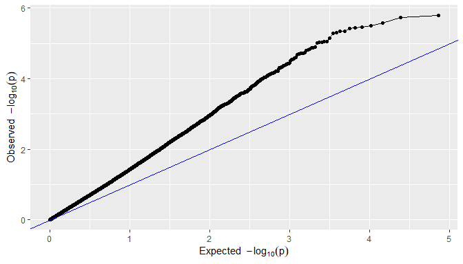

```r
## Plot a qq plot of GWAS Drops.
plot(GWASDrops, plotType = "qq")
```

#### Manhattan plots

A Manhattan plot is made by setting `plotType = "manhattan"`. Significant SNPs are marked in red.

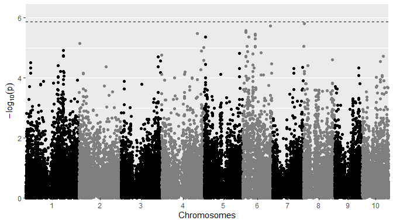

```r
## Plot a manhattan plot of GWAS Drops.
plot(GWASDrops, plotType = "manhattan")
```

More options linked with `plotType = "manhattan"` are described in the `statgenGWAS` vignette.

#### QTL plots

A qtl plot can be made by setting `plotType = "qtl"`. In this plot the significant SNPs are marked by circles at their genomic positions, with diameter proportional to the estimated effect size; for an example see Millet et al. (2016). Typically, this is done for multiple traits or environments, with the genomic position on the x-axis, which are displayed horizontally above each other and can thus be compared.

Since the traits are measured on a different scale, the effect estimates cannot be compared directly. For better comparison, one can set `normalize = TRUE`, which divides the estimates by the standard deviation of the phenotype.

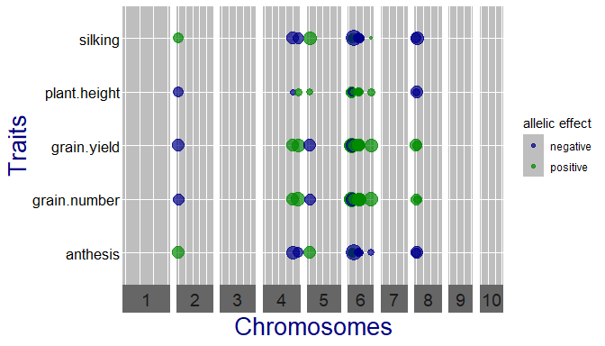

```r
## Plot a qtl plot of GWAS Drops for Mur13W.
## Set significance threshold to 5 and normalize effect estimates.
plot(GWASDrops, plotType = "qtl", yThr = 5, normalize = TRUE)
```

Other arguments can be used to plot a subset of the chromosomes (`chr`) and directly export the plot to .pptx (`exportPptx = TRUE` and specify `pptxName`). Note that the [officer](https://ardata-fr.github.io/officeverse/) package is required for this. A full list of arguments can be found by running `help(plot.GWAS)`.

## Kinship matrices

The `runMultiTraitGwas()` function has an argument `kinshipMethod`, which defines the kinship matrix used for association mapping. Kinship matrices can be computed directly using the `kinship` function or within the `runMultiTraitGwas function`. There are five options: (1) using the covariance between the scaled SNP-scores (`kinshipMethod = "astle"`, the default; see e.g. equation (2.2) in Astle and Balding (2009)) (2) Identity by State (`kinshipMethod = "IBS"`; see e.g. equation (2.3) in Astle and Balding (2009)) (3) using the formula by VanRaden (2008) (`kinshipMethod = "vanRaden"`) (4) using an identity matrix (`kinshipMethod = "identity"`), corresponding to no kinship correction (5) User-defined, in which case the argument `kin` needs to be specified.

By default, the same kinship matrix is used for testing all SNPs (`GLSMethod = "single"`). When `GLSMethod = "multi"`, the kinship matrix is chromosome-specific. In this case, the function fits variance components and computes effect-estimates and P-values for each chromosome in turn, using the kinship matrix for that chromosome (i.e. using all SNPs that are **not** on this chromosome). Each chromosome-specific kinship matrix is computed using the method specified by the argument `kinshipMethod`. As shown by Rincent et al. (2014), this can give a considerable improvement in power.

```r
## Run multi-trait GWAS for trial 'Mur13W'.
## Use chromosome specific kinship matrices computed using method of van Raden.
GWASDropsChrSpec <- runMultiTraitGwas(gData = gDataDropsDedup,
                                      trials = "Mur13W",
                                      GLSMethod = "multi",
                                      kinshipMethod = "vanRaden",
                                      covModel = "fa")
```

# Worked example 2: one trait measured in multiple trials

## **Create gData object**

In this example, we will focus on one trait, grain yield, in all trials. `dropsPheno` contains genotypic means for 10 trials. To be able to run a GWAS analysis with one trait measured in all trials, the data has to be reshaped and added as a single data.frame with “genotype” as first column and traits after that.

```r
## Reshape phenotypic data to data.frame in wide format containing only grain.yield.
phenoDat <- reshape(dropsPheno[, c("Experiment", "genotype", "grain.yield")],
                    timevar = "Experiment",
                    idvar = "genotype",
                    direction = "wide",
                    v.names = "grain.yield")
## Rename columns to trial name only.
colnames(phenoDat)[2:ncol(phenoDat)] <-
  gsub(pattern = "grain.yield.", replacement = "",
       x = colnames(phenoDat)[2:ncol(phenoDat)])
```

Now we create a `gData` object containing map marker information and phenotypes.

```r
## Create a gData object containing map, marker and phenotypic information.
gDataDropsxE <- statgenGWAS::createGData(geno = dropsMarkers,
                                         map = dropsMap,
                                         pheno = phenoDat)
summary(gDataDropsxE)
```

```
#> map
#>  Number of markers: 41722
#>  Number of chromosomes: 10
#>
#> markers
#>  Number of markers: 41722
#>  Number of genotypes: 246
#>  Content:
#>      0    1    2 <NA>
#>   0.28 0.01 0.71 0.00
#>
#> pheno
#>  Number of trials: 1
#>
#>  phenoDat:
#>      Number of traits: 10
#>      Number of genotypes: 246
#>
#>         Kar12W Gai12W Kar13W Ner12R Mar13R Mur13R Cra12R Cam12R Kar13R Mur13W
#> Min.       5.4    7.5    4.1    2.1    3.8    2.1  0.088   0.38    5.6    3.3
#> 1st Qu.    8.8   10.4    7.0    4.0    7.0    5.8  0.891   1.33    8.7    6.3
#> Median     9.9   11.2    7.9    4.7    7.7    6.9  1.381   1.87    9.8    7.5
#> Mean       9.7   11.2    8.0    4.7    7.8    6.9  1.492   1.98    9.9    7.4
#> 3rd Qu.   10.7   12.0    9.1    5.3    8.6    7.8  1.971   2.59   11.0    8.4
#> Max.      13.1   14.3   12.7    7.1   11.5   10.6  4.979   4.90   13.8   11.4
#> NA's       0.0    0.0    0.0    0.0    0.0    0.0  0.000   0.00    0.0    0.0
```

## **Recoding and cleaning of markers**

```r
## Remove duplicate SNPs from gDataDrops.
gDataDropsDedupxE <- statgenGWAS::codeMarkers(gDataDropsxE,
                                              impute = FALSE,
                                              verbose = TRUE)
```

```
#> Input contains 41722 SNPs for 246 genotypes.
#> 0 genotypes removed because proportion of missing values larger than or equal to 1.
#> 0 SNPs removed because proportion of missing values larger than or equal to 1.
#> 5098 duplicate SNPs removed.
#> Output contains 36624 SNPs for 246 genotypes.
```

## **Multi-trial GWAS**

Similar to the first example we run a multi-trial GWAs using a factor analytic model.

```r
## Run multi-trial GWAS for one trait in all trials.
GWASDropsxE <- runMultiTraitGwas(gData = gDataDropsDedupxE,
                                 covModel = "fa")
```

Among the significant SNPs we find the large QTL on chromosome 6 reported in Millet et al. (2016).

```r
head(GWASDropsxE$signSnp$pheno, row.names = FALSE)
```

```
#>              snp  trait   chr      pos  pValue   LOD effect effectSe allFreq       snpStatus propSnpVar
#>           <char> <char> <int>    <int>   <num> <num>  <num>    <num>   <num>          <fctr>      <num>
#> 1:      SYN25281 Kar12W     6 18646369 1.6e-07   6.8   0.23    0.100    0.79 significant SNP      0.017
#> 2: PZE-106021363 Kar12W     6 18846283 7.4e-11  10.1   0.28    0.091    0.70 significant SNP      0.034
#> 3: PZE-106021410 Kar12W     6 18990291 2.5e-11  10.6   0.30    0.091    0.70 significant SNP      0.037
#> 4: PZE-106021419 Kar12W     6 18991091 1.5e-12  11.8   0.26    0.092    0.74 significant SNP      0.026
#> 5: PZE-106021420 Kar12W     6 18991117 2.2e-10   9.6   0.27    0.091    0.70 significant SNP      0.032
#> 6: PZE-106021424 Kar12W     6 18991481 4.2e-12  11.4   0.24    0.092    0.74 significant SNP      0.022
```

### GWAS Summary

For a quick overview of the results, e.g. the number of significant SNPs, we again use the summary function. We restrict the output to two trials using the `traits` argument.

```r
summary(GWASDropsxE, traits = c("Mur13W", "Kar12W"))
```

```
#> phenoDat:
#>  Traits analysed: Cam12R, Cra12R, Gai12W, Kar12W, Kar13R, Kar13W, Mar13R, Mur13R, Mur13W, Ner12R
#>
#>  Data are available for 36624 SNPs.
#>   0 of them were not analyzed because their minor allele frequency is below 0.01
#>
#>  GLSMethod: single
#>
#>  Trait: Mur13W
#>
#>      LOD-threshold: 5.9
#>      Number of significant SNPs: 8
#>      Smallest p-value among the significant SNPs: 1.5e-12
#>      Largest p-value among the significant SNPs: 3.9e-07 (LOD-score: 6.4)
#>
#>      No genomic control correction was applied
#>      Genomic control inflation-factor: 0.94
#>
#>  Trait: Kar12W
#>
#>      LOD-threshold: 5.9
#>      Number of significant SNPs: 8
#>      Smallest p-value among the significant SNPs: 1.5e-12
#>      Largest p-value among the significant SNPs: 3.9e-07 (LOD-score: 6.4)
#>
#>      No genomic control correction was applied
#>      Genomic control inflation-factor: 0.94
```

### GWAS Plots

As in the first example we use the `plot.GWAS()` function to visualize the results in `GWASDropsxE`, with a QQ-plot, Manhattan plot or QTL-plot.

#### QQ plots

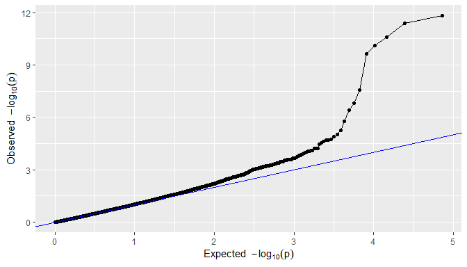

```r
plot(GWASDropsxE, plotType = "qq")
```

#### Manhattan plots

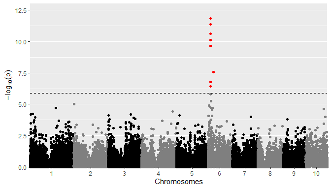

```r
plot(GWASDropsxE, plotType = "manhattan")
```

#### QTL plots

The trait is measured with the same scale across trials so the effect estimates can be compared directly (one can set `normalize = FALSE`).

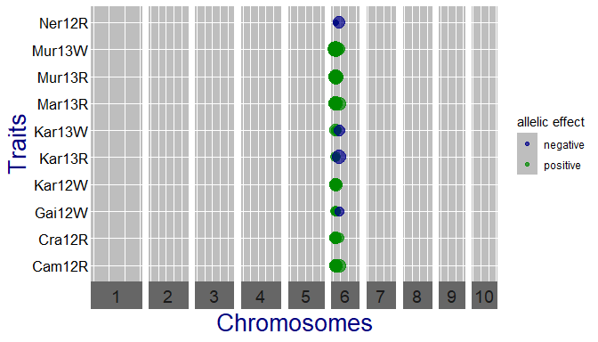

```r
## Set significance threshold to 6 and do not normalize effect estimates.
plot(GWASDropsxE, plotType = "qtl", yThr = 6, normalize = FALSE)
```